# SE Seminar

David Issa Mattos

1/26/2021

# Packages

```r
library(bpcs)
library(tidyverse)
library(knitr)
library(kableExtra)
options(mc.cores = parallel::detectCores())
rstan::rstan_options(auto_write = TRUE)
set.seed(99)
```

# Gorillas using touchscreen

> Huskisson, S.M., Jacobson, S.L., Egelkamp, C.L. et al. Using a Touchscreen Paradigm to Evaluate Food Preferences and Response to Novel Photographic Stimuli of Food in Three Primate Species (Gorilla gorilla gorilla, Pan troglodytes, and Macaca fuscata). Int J Primatol 41, 5–23 (2020). https://doi.org/10.1007/s10764-020-00131-0

Let’s import the data and select only the gorillas

```r
d <- readr::read_csv('data/touchscreen.csv') %>%
  dplyr::filter(species_type=='Gorilla') %>%
  dplyr::select(species_type, SubjectCode, Trial, image1, image2, image_chosen)
```

Let’s create a column that says which image was selected 1 for image2 0 for image 1

```r
d <- d %>%
  dplyr::mutate(y =ifelse(image_chosen==image1, 0, 1)) %>%
  select(-image_chosen)
```

Let’s also do some recoding to facilitate interpreting

```r
d$image1 <- dplyr::recode(d$image1, "Ca" = 'Carrot')
d$image1 <- dplyr::recode(d$image1, "Cu" = 'Cucumber')
d$image1 <- dplyr::recode(d$image1, "Tu" = 'Turnip')
d$image1 <- dplyr::recode(d$image1, "Gr" = 'Grape')
d$image1 <- dplyr::recode(d$image1, "To" = 'Tomato')
d$image1 <- dplyr::recode(d$image1, "Ap" = 'Apple')

d$image2 <- dplyr::recode(d$image2, "Ca" = 'Carrot')
d$image2 <- dplyr::recode(d$image2, "Cu" = 'Cucumber')
d$image2 <- dplyr::recode(d$image2, "Tu" = 'Turnip')
d$image2 <- dplyr::recode(d$image2, "Gr" = 'Grape')
d$image2 <- dplyr::recode(d$image2, "To" = 'Tomato')
d$image2 <- dplyr::recode(d$image2, "Ap" = 'Apple')
```

Sample of the data

```r
d %>%
  dplyr::sample_n(size=10) %>%
  kable() %>%
  kableExtra::kable_styling(bootstrap_options = c("striped", "hover", "condensed", "responsive")) %>%
  kableExtra::scroll_box(width = "100%")
```

| species_type | SubjectCode | Trial | image1 | image2 | y |
| --- | --- | --- | --- | --- | --- |
| Gorilla | Gorilla3 | 2 | Grape | Cucumber | 0 |
| Gorilla | Gorilla6 | 16 | Grape | Turnip | 0 |
| Gorilla | Gorilla6 | 14 | Grape | Tomato | 1 |
| Gorilla | Gorilla2 | 2 | Apple | Tomato | 0 |
| Gorilla | Gorilla4 | 14 | Apple | Turnip | 0 |
| Gorilla | Gorilla4 | 5 | Carrot | Grape | 0 |
| Gorilla | Gorilla5 | 13 | Tomato | Turnip | 0 |
| Gorilla | Gorilla5 | 13 | Apple | Carrot | 0 |
| Gorilla | Gorilla6 | 21 | Carrot | Grape | 1 |
| Gorilla | Gorilla5 | 28 | Apple | Turnip | 0 |

Now we can run a Bradley-Terry model with the bpcs package

```r
m1_gor <-
  bpc(
    d,
    player0 = 'image1',
    player1 = 'image2',
    result_column = 'y',
    model_type = 'bt',
    priors = list(prior_lambda_std = 0.5),
    iter = 3000
  )
save_bpc_model(m1_gor, 'm1_gor', 'fittedmodels')
```

Now that we got our posterior we can look at some interesting tables and plots

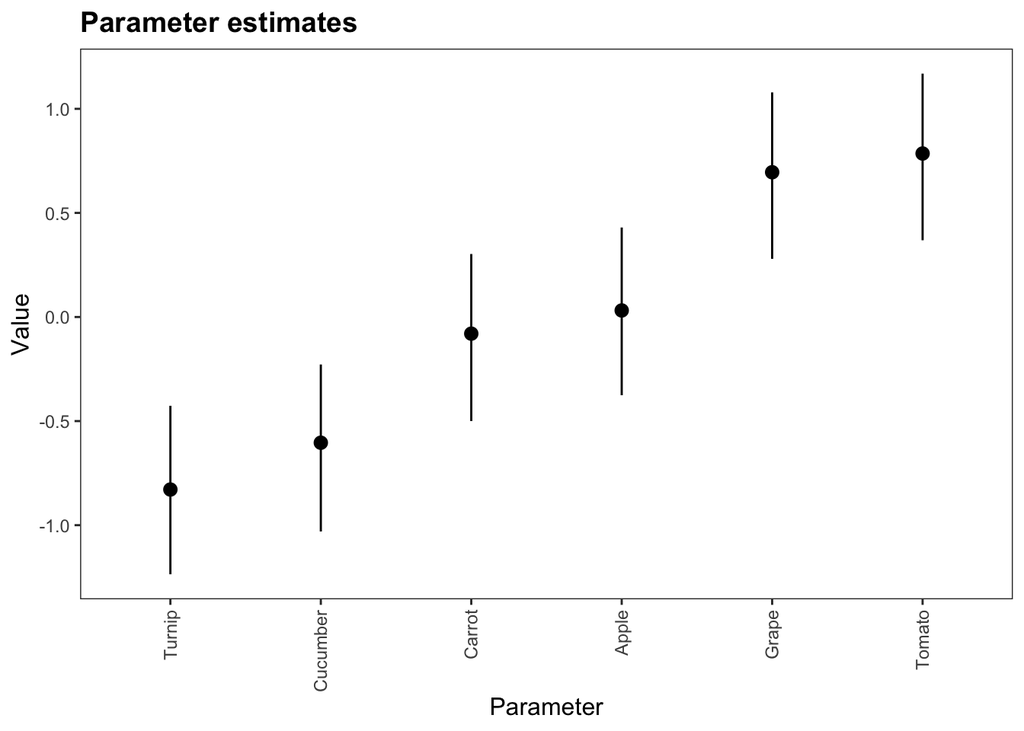

```r
plot(m1_gor, rotate_x_labels = T)+
  scale_x_discrete(
  labels = c(
    "Turnip",
    "Cucumber",
    "Carrot",
    "Apple",
    "Grape",
    "Tomato"
  ))
```

Getting a probability table

```r
get_probabilities_table(m1_gor, format='html')
```

Estimated posterior probabilites

| i | j | i_beats_j | j_beats_i |
| --- | --- | --- | --- |
| Apple | Carrot | 0.54 | 0.46 |
| Apple | Cucumber | 0.68 | 0.32 |
| Apple | Grape | 0.36 | 0.64 |
| Apple | Tomato | 0.39 | 0.61 |
| Apple | Turnip | 0.74 | 0.26 |
| Carrot | Cucumber | 0.64 | 0.36 |
| Carrot | Grape | 0.25 | 0.75 |
| Carrot | Tomato | 0.26 | 0.74 |
| Carrot | Turnip | 0.73 | 0.27 |
| Cucumber | Grape | 0.15 | 0.85 |
| Cucumber | Tomato | 0.17 | 0.83 |
| Cucumber | Turnip | 0.51 | 0.49 |
| Grape | Tomato | 0.58 | 0.42 |
| Grape | Turnip | 0.83 | 0.17 |
| Tomato | Turnip | 0.83 | 0.17 |

# Automated labeling

Let’s start importing the data

```r
d2 <- read_csv('./data/auto-label-comparison.csv') %>%
  dplyr::rename(Value='value') %>%
  dplyr::filter(ValueType=='accuracy') %>%
  dplyr::filter(Model=='LabelPropagation_knn' |
                Model=='LabelPropagation_rbf' |
                Model=='LabelSpreading_knn' |
                Model=='LabelSpreading_rbf')
```

Lets visualize

```r
d2 %>%
  dplyr::sample_n(size=10) %>%
  kable() %>%
  kableExtra::kable_styling(bootstrap_options = c("striped", "hover", "condensed", "responsive")) %>%
  kableExtra::scroll_box(width = "100%")
```

| X1 | ValueType | Value | Iteration | Variable | Model | Dataset | DataType |
| --- | --- | --- | --- | --- | --- | --- | --- |
| 27 | accuracy | 0.6967609 | 7 | 50% | LabelSpreading_rbf | digits | image |
| 22 | accuracy | 0.3333333 | 2 | 50% | LabelSpreading_knn | corpus | text |
| 23 | accuracy | 0.1666667 | 3 | 50% | LabelPropagation_knn | reuters | text |
| 8 | accuracy | 0.0181818 | 8 | 10% | LabelPropagation_rbf | cifar | image |
| 28 | accuracy | 0.0004808 | 8 | 50% | LabelPropagation_rbf | cifar2 | image |
| 24 | accuracy | 0.2756910 | 4 | 50% | LabelPropagation_knn | german | numeric |
| 4 | accuracy | 0.0181818 | 4 | 10% | LabelPropagation_knn | mnist | image |
| 9 | accuracy | 0.1666667 | 9 | 10% | LabelPropagation_knn | reuters | text |
| 1 | accuracy | 0.1280959 | 1 | 10% | LabelPropagation_rbf | 20news | text |
| 20 | accuracy | 0.2635986 | 0 | 50% | LabelPropagation_knn | musk1 | numeric |

```r
d_acc_rank <- d2 %>%
  dplyr::group_by(Dataset, Variable, Iteration) %>%
  dplyr::mutate(Rank=-rank(Value, ties.method = 'random')) %>%
  dplyr::ungroup() %>%
  dplyr::select(-Value) %>% #we need to drop the Value variable to pivot wider
  tidyr::pivot_wider(names_from = Model,
                     values_from=Rank)
```

Expanding it

```r
models<-unique(d2$Model)
n_models = length(models)
comb <- gtools::combinations(n=n_models, r=2, v=seq(1:n_models), repeats.allowed = F) #all teh paired combinations

d_acc_bt <-  dplyr::tribble(~model0, ~model1, ~y, ~Iteration, ~Dataset, ~DatasetType)

#now we loop each row of the rank wide dataset and create a new one
for(i in 1:nrow(d_acc_rank))
{
  current_row <- d_acc_rank[i,]
  for(j in 1:nrow(comb)){
    comb_row <- comb[j,]

    model0 <- models[comb_row[1]]
    model0_rank <- current_row[[1,model0]]

    model1 <- models[comb_row[2]]
    model1_rank <- current_row[[1,model1]]

    diff_rank <- model1_rank - model0_rank
    #SInce higher accuracy is better if model 1 rank- model 0 rank is positive than model1 wins and y=1 else y=0
    y <- ifelse(diff_rank>0, 1, 0)


    d_acc_bt <-d_acc_bt %>%
      add_row(model0=model0,
              model1=model1,
              y=y,
              Iteration=current_row$Iteration,
              Dataset=current_row$Dataset,
              DatasetType=current_row$DataType)

  }
}
```

```r
d_acc_bt %>%
  dplyr::sample_n(size=20) %>%
  kable() %>%
  kableExtra::kable_styling(bootstrap_options = c("striped", "hover", "condensed", "responsive")) %>%
  kableExtra::scroll_box(width = "100%")
```

| model0 | model1 | y | Iteration | Dataset | DatasetType |
| --- | --- | --- | --- | --- | --- |
| LabelPropagation_rbf | LabelSpreading_rbf | 1 | 0 | wine | numeric |
| LabelSpreading_knn | LabelSpreading_rbf | 0 | 8 | wine | numeric |
| LabelPropagation_rbf | LabelSpreading_knn | 0 | 5 | corpus | text |
| LabelPropagation_rbf | LabelSpreading_rbf | 0 | 6 | wine | numeric |
| LabelPropagation_knn | LabelPropagation_rbf | 1 | 3 | cifar | image |
| LabelPropagation_rbf | LabelSpreading_rbf | 0 | 0 | corpus | text |
| LabelPropagation_knn | LabelSpreading_rbf | 0 | 7 | 20news | text |
| LabelPropagation_knn | LabelSpreading_rbf | 0 | 8 | reuters | text |
| LabelPropagation_rbf | LabelSpreading_knn | 0 | 5 | musk1 | numeric |
| LabelSpreading_knn | LabelSpreading_rbf | 1 | 9 | cifar | image |
| LabelPropagation_knn | LabelSpreading_rbf | 0 | 1 | 20news | text |
| LabelPropagation_rbf | LabelSpreading_rbf | 1 | 4 | ohsumed | text |
| LabelSpreading_knn | LabelSpreading_rbf | 1 | 5 | cifar | image |
| LabelSpreading_knn | LabelSpreading_rbf | 0 | 1 | mnist | image |
| LabelSpreading_knn | LabelSpreading_rbf | 1 | 9 | iris | numeric |
| LabelPropagation_knn | LabelSpreading_knn | 0 | 3 | corpus | text |
| LabelPropagation_rbf | LabelSpreading_rbf | 0 | 9 | cifar2 | image |
| LabelPropagation_knn | LabelSpreading_knn | 1 | 8 | digits | image |
| LabelPropagation_rbf | LabelSpreading_knn | 1 | 9 | ohsumed | text |
| LabelPropagation_knn | LabelSpreading_knn | 1 | 1 | corpus | text |

Now we can do some paired comparison models

```r
m1_autol <-
  bpc(
    d_acc_bt,
    player0 = 'model0',
    player1 = 'model1',
    result_column = 'y',
    model_type = 'bt-U',
    cluster = c("Dataset"),
    priors = list(prior_lambda_std = 0.5, prior_U1_std=1.0),
    iter = 3000
  )
save_bpc_model(m1_autol, 'm1_autol', 'fittedmodels')
```

```r
get_probabilities_table(m1_autol, format = 'html', model_type = 'bt')
```

Estimated posterior probabilites

| i | j | i_beats_j | j_beats_i |
| --- | --- | --- | --- |
| LabelPropagation_knn | LabelPropagation_rbf | 0.33 | 0.67 |
| LabelPropagation_knn | LabelSpreading_knn | 0.45 | 0.55 |
| LabelPropagation_knn | LabelSpreading_rbf | 0.45 | 0.55 |
| LabelPropagation_rbf | LabelSpreading_knn | 0.62 | 0.38 |
| LabelPropagation_rbf | LabelSpreading_rbf | 0.56 | 0.44 |
| LabelSpreading_knn | LabelSpreading_rbf | 0.41 | 0.59 |

```r
get_rank_of_players_table(m1_autol, format = 'html')
```

Estimated posterior ranks

| Parameter | MedianRank | MeanRank | StdRank |
| --- | --- | --- | --- |
| lambda[LabelPropagation_rbf] | 1 | 1.426 | 0.756 |
| lambda[LabelPropagation_knn] | 3 | 2.700 | 0.976 |
| lambda[LabelSpreading_knn] | 3 | 2.812 | 0.959 |
| lambda[LabelSpreading_rbf] | 3 | 3.062 | 0.976 |

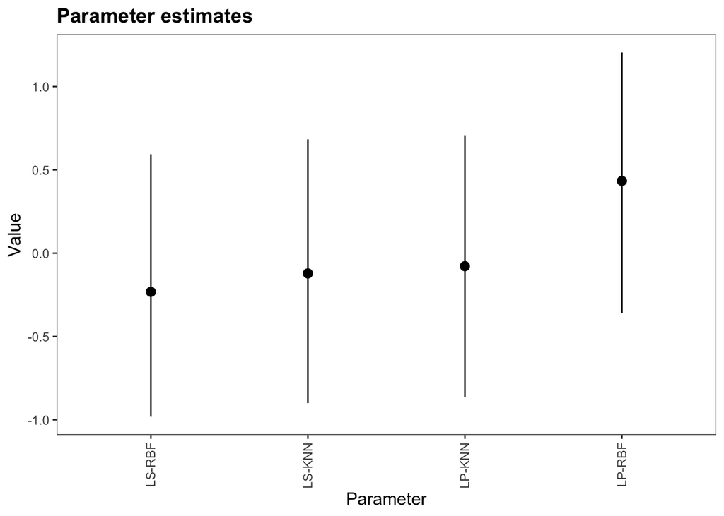

```r
plot(m1_autol, rotate_x_labels = T)+
  scale_x_discrete(
  labels = c(
    "LS-RBF",
    "LS-KNN",
    "LP-KNN",
    "LP-RBF"
  ))
```

# Football

The data comes in the bpcs package

```r
data("brasil_soccer_league")
knitr::kable(head(brasil_soccer_league))
```

| Time | WeekDay | Date | HomeTeam | VisitorTeam | Round | Stadium | ScoreHomeTeam | ScoreVisitorTeam |
| --- | --- | --- | --- | --- | --- | --- | --- | --- |
| 16:00 | Saturday | 2017-05-13 | Flamengo | Atlético-MG | 1 | Maracanã | 1 | 1 |
| 19:00 | Saturday | 2017-05-13 | Corinthians | Chapecoense | 1 | Arena Corinthians | 1 | 1 |
| 16:00 | Sunday | 2017-05-14 | Avaí | Vitória | 1 | Ressacada | 0 | 0 |
| 16:00 | Sunday | 2017-05-14 | Bahia | Athlético-PR | 1 | Fonte Nova | 6 | 2 |
| 16:00 | Sunday | 2017-05-14 | Cruzeiro | São Paulo | 1 | Mineirão | 1 | 0 |
| 11:00 | Sunday | 2017-05-14 | Fluminense | Santos | 1 | Maracanã | 3 | 2 |

Let’s analyze only the data from 2019 and remove a few columns that are not relevant for this example:

```r
d3 <- brasil_soccer_league %>%
  dplyr::filter(Date >= as.Date("2019-01-01") &
                  Date <= as.Date("2019-12-31")) %>%
  dplyr::select(HomeTeam, VisitorTeam, ScoreHomeTeam, ScoreVisitorTeam, Round)
```

```r
m_football <- bpc(d3,
          player0 = 'VisitorTeam',
          player1 =  'HomeTeam',
          player0_score = 'ScoreVisitorTeam',
          player1_score = 'ScoreHomeTeam',
          model_type = 'davidson',
          solve_ties = 'none',
          priors = list(prior_lambda_std=2.0), # making a more informative prior to improve convergence
          iter = 3000) #stan indicates a low bulk ESS so we are increasing the number of iterations
save_bpc_model(m_football, 'm_football', 'fittedmodels')
```

Getting the table with the parameters:

```r
get_parameters_table(m_football, format = 'html')
```

Parameters estimates

| Parameter | Mean | HPD_lower | HPD_higher |
| --- | --- | --- | --- |
| lambda[Avaí] | -1.912 | -3.331 | -0.627 |
| lambda[Internacional] | 0.162 | -1.031 | 1.440 |
| lambda[Cruzeiro] | -0.683 | -1.921 | 0.520 |
| lambda[Botafogo-rj] | -0.584 | -1.862 | 0.637 |
| lambda[Vasco] | -0.067 | -1.286 | 1.137 |
| lambda[Corinthians] | 0.310 | -0.867 | 1.576 |
| lambda[CSA] | -1.101 | -2.368 | 0.143 |
| lambda[Goiás] | -0.061 | -1.335 | 1.122 |
| lambda[Fortaleza] | 0.133 | -1.107 | 1.352 |
| lambda[Santos] | 1.070 | -0.217 | 2.291 |
| lambda[Grêmio] | 0.631 | -0.573 | 1.912 |
| lambda[Palmeiras] | 1.245 | -0.011 | 2.514 |
| lambda[Atlético-MG] | -0.048 | -1.340 | 1.133 |
| lambda[Chapecoense] | -0.986 | -2.280 | 0.272 |
| lambda[Ceará] | -0.729 | -2.022 | 0.433 |
| lambda[Athlético-PR] | 0.717 | -0.580 | 1.919 |
| lambda[Flamengo] | 2.042 | 0.696 | 3.372 |
| lambda[São Paulo] | 0.616 | -0.654 | 1.849 |
| lambda[Bahia] | -0.129 | -1.353 | 1.098 |
| lambda[Fluminense] | -0.378 | -1.594 | 0.903 |
| nu | 0.385 | 0.159 | 0.624 |

Ranking the teams

```r
get_rank_of_players_table(m_football, format = 'html')
```

Estimated posterior ranks

| Parameter | MedianRank | MeanRank | StdRank |
| --- | --- | --- | --- |
| lambda[Flamengo] | 1 | 1.286 | 0.692 |
| lambda[Palmeiras] | 3 | 3.195 | 1.920 |
| lambda[Santos] | 3 | 3.746 | 1.946 |
| lambda[Athlético-PR] | 5 | 5.633 | 2.810 |
| lambda[Grêmio] | 6 | 6.027 | 2.972 |
| lambda[São Paulo] | 6 | 6.022 | 2.800 |
| lambda[Corinthians] | 8 | 8.073 | 3.065 |
| lambda[Fortaleza] | 9 | 9.455 | 3.391 |
| lambda[Internacional] | 9 | 9.252 | 3.445 |
| lambda[Atlético-MG] | 11 | 10.880 | 3.472 |
| lambda[Goiás] | 11 | 10.969 | 3.493 |
| lambda[Vasco] | 11 | 10.975 | 3.362 |
| lambda[Bahia] | 12 | 11.527 | 3.395 |
| lambda[Fluminense] | 14 | 13.380 | 3.363 |
| lambda[Botafogo-rj] | 15 | 14.759 | 3.008 |
| lambda[Ceará] | 16 | 15.401 | 2.785 |
| lambda[Cruzeiro] | 16 | 15.271 | 2.865 |
| lambda[Chapecoense] | 18 | 17.036 | 2.276 |
| lambda[CSA] | 18 | 17.419 | 2.145 |
| lambda[Avaí] | 20 | 19.694 | 0.733 |

Plot

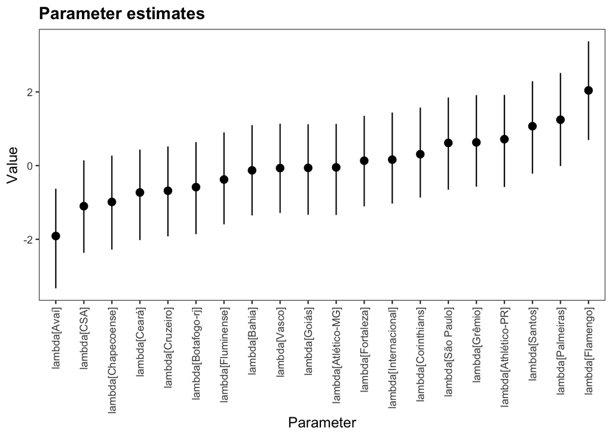

```r
plot(m_football, rotate_x_labels = T)
```